# The Labyrinth of Multiple Testing: how to avoid the pitfall of false positives

# 4 Post-Hoc

We analyze the `litter` dataset where four dosages ($0$, $5$, $50$, $500$) are administrated to pregenant mice and their litters were evaluated for birth weights as average post-birth weights in the entire litter.

We perform one test for each comparison (i.e., $5$ versus $0$, $50$ versus $0$, $500$ versus $0$, $50$ versus $5$ and so on).

```r
library(multcomp)
data(litter)
head(litter)
```

|  | dose | weight | gesttime | number |
| --- | --- | --- | --- | --- |
| 1 | 0 | 28.05 | 22.5 | 15 |
| 2 | 0 | 33.33 | 22.5 | 14 |
| 3 | 0 | 36.37 | 22.0 | 14 |
| 4 | 0 | 35.52 | 22.0 | 13 |
| 5 | 0 | 36.77 | 21.5 | 15 |
| 6 | 0 | 29.60 | 23.0 | 5 |

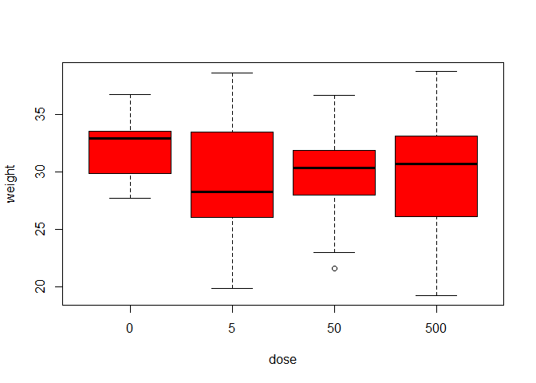

```r
#### Let see the distribution of weights across different dosages
boxplot(weight~dose,data=litter,col="red")
```

```r
#### Here we perform an analysis of variance, but we are interested on post-hoc comparison
amod <- aov(weight ~ dose + gesttime + number, data = litter)

### Define matrix of linear hypotheses for 'dose'
K <- contrMat(table(litter$dose), "Tukey")

### Set up multiple comparison object
Kht <- glht(amod, linfct = mcp(dose = K), alternative = "less")

summary(Kht, test = univariate())
```

```
##
##   Simultaneous Tests for General Linear Hypotheses
##
## Multiple Comparisons of Means: User-defined Contrasts
##
##
## Fit: aov(formula = weight ~ dose + gesttime + number, data = litter)
##
## Linear Hypotheses:
##               Estimate Std. Error t value  Pr(<t)
## 5 - 0 >= 0     -3.3524     1.2908  -2.597 0.00575 **
## 50 - 0 >= 0    -2.2909     1.3384  -1.712 0.04576 *
## 500 - 0 >= 0   -2.6752     1.3343  -2.005 0.02448 *
## 50 - 5 >= 0     1.0615     1.3973   0.760 0.77498
## 500 - 5 >= 0    0.6772     1.3394   0.506 0.69260
## 500 - 50 >= 0  -0.3844     1.4510  -0.265 0.39595
## ---
## Signif. codes:  0 '***' 0.001 '**' 0.01 '*' 0.05 '.' 0.1 ' ' 1
## (Univariate p values reported)
```

```r
summary(Kht, test = adjusted("bonferroni"))
```

```
##
##   Simultaneous Tests for General Linear Hypotheses
##
## Multiple Comparisons of Means: User-defined Contrasts
##
##
## Fit: aov(formula = weight ~ dose + gesttime + number, data = litter)
##
## Linear Hypotheses:
##               Estimate Std. Error t value Pr(<t)
## 5 - 0 >= 0     -3.3524     1.2908  -2.597 0.0345 *
## 50 - 0 >= 0    -2.2909     1.3384  -1.712 0.2745
## 500 - 0 >= 0   -2.6752     1.3343  -2.005 0.1469
## 50 - 5 >= 0     1.0615     1.3973   0.760 1.0000
## 500 - 5 >= 0    0.6772     1.3394   0.506 1.0000
## 500 - 50 >= 0  -0.3844     1.4510  -0.265 1.0000
## ---
## Signif. codes:  0 '***' 0.001 '**' 0.01 '*' 0.05 '.' 0.1 ' ' 1
## (Adjusted p values reported -- bonferroni method)
```

```r
summary(Kht, test = adjusted("holm"))
```

```
##
##   Simultaneous Tests for General Linear Hypotheses
##
## Multiple Comparisons of Means: User-defined Contrasts
##
##
## Fit: aov(formula = weight ~ dose + gesttime + number, data = litter)
##
## Linear Hypotheses:
##               Estimate Std. Error t value Pr(<t)
## 5 - 0 >= 0     -3.3524     1.2908  -2.597 0.0345 *
## 50 - 0 >= 0    -2.2909     1.3384  -1.712 0.1830
## 500 - 0 >= 0   -2.6752     1.3343  -2.005 0.1224
## 50 - 5 >= 0     1.0615     1.3973   0.760 1.0000
## 500 - 5 >= 0    0.6772     1.3394   0.506 1.0000
## 500 - 50 >= 0  -0.3844     1.4510  -0.265 1.0000
## ---
## Signif. codes:  0 '***' 0.001 '**' 0.01 '*' 0.05 '.' 0.1 ' ' 1
## (Adjusted p values reported -- holm method)
```

## Exercise 4: PlantGrowth data

Consider the `PlantGrowth` in `library(datasets)`:

Results from an experiment to compare yields (as measured by dried weight of plants) obtained under a control and two different treatment conditions.

```r
data(PlantGrowth)
#?PlantGrowth
str(PlantGrowth)
```

```
## 'data.frame':    30 obs. of  2 variables:
##  $ weight: num  4.17 5.58 5.18 6.11 4.5 4.61 5.17 4.53 5.33 5.14 ...
##  $ group : Factor w/ 3 levels "ctrl","trt1",..: 1 1 1 1 1 1 1 1 1 1 ...
```

We are interested in all possible pair-wise comparisons of the three groups. Perform a parametric analysis and correct for post-hoc (i.e. multiple testing) using

- Bonferroni
- Holm

Do this without the help of `library(multcomp)` (or any other specialized libraries/softwares), also showing step-by-step the calculation performed.

Compare your results with the ones of `library(multcomp)` (or any other specialized libraries/softwares).

**Possible solution**

```r
pv1 <- t.test(PlantGrowth$weight[PlantGrowth$group == "ctrl"],PlantGrowth$weight[PlantGrowth$group == "trt1"])$p.value

pv2 <- t.test(PlantGrowth$weight[PlantGrowth$group == "ctrl"],PlantGrowth$weight[PlantGrowth$group == "trt2"])$p.value

pv3 <- t.test(PlantGrowth$weight[PlantGrowth$group == "trt1"],PlantGrowth$weight[PlantGrowth$group == "trt2"])$p.value

p.adjust(c(pv1,pv2,pv3), method = "bonferroni")
```

```
## [1] 0.75114753 0.14369777 0.02789521
```

```r
p.adjust(c(pv1,pv2,pv3), method = "holm")
```

```
## [1] 0.25038251 0.09579851 0.02789521
```

using `library(multcomp)`:

```r
library(multcomp)
amod <- aov(weight ~ group, data = PlantGrowth)

Kht <- glht(amod, linfct = mcp(group = c("ctrl - trt1 = 0",
                                         "ctrl - trt2 = 0",
                                         "trt1 - trt2 = 0")))


summary(Kht, test = adjusted("bonferroni"))
```

```
##
##   Simultaneous Tests for General Linear Hypotheses
##
## Multiple Comparisons of Means: User-defined Contrasts
##
##
## Fit: aov(formula = weight ~ group, data = PlantGrowth)
##
## Linear Hypotheses:
##                  Estimate Std. Error t value Pr(>|t|)
## ctrl - trt1 == 0   0.3710     0.2788   1.331   0.5832
## ctrl - trt2 == 0  -0.4940     0.2788  -1.772   0.2630
## trt1 - trt2 == 0  -0.8650     0.2788  -3.103   0.0134 *
## ---
## Signif. codes:  0 '***' 0.001 '**' 0.01 '*' 0.05 '.' 0.1 ' ' 1
## (Adjusted p values reported -- bonferroni method)
```

```r
summary(Kht, test = adjusted("holm"))
```

```
##
##   Simultaneous Tests for General Linear Hypotheses
##
## Multiple Comparisons of Means: User-defined Contrasts
##
##
## Fit: aov(formula = weight ~ group, data = PlantGrowth)
##
## Linear Hypotheses:
##                  Estimate Std. Error t value Pr(>|t|)
## ctrl - trt1 == 0   0.3710     0.2788   1.331   0.1944
## ctrl - trt2 == 0  -0.4940     0.2788  -1.772   0.1754
## trt1 - trt2 == 0  -0.8650     0.2788  -3.103   0.0134 *
## ---
## Signif. codes:  0 '***' 0.001 '**' 0.01 '*' 0.05 '.' 0.1 ' ' 1
## (Adjusted p values reported -- holm method)
```

## Exercise 5: InsectSprays data

Consider the `InsectSprays` in `library(datasets)`:

The counts of insects in agricultural experimental units treated with different insecticides.

```r
data(InsectSprays)
#?InsectSprays
str(InsectSprays)
```

```
## 'data.frame':    72 obs. of  2 variables:
##  $ count: num  10 7 20 14 14 12 10 23 17 20 ...
##  $ spray: Factor w/ 6 levels "A","B","C","D",..: 1 1 1 1 1 1 1 1 1 1 ...
```

Same task as previous Exercise.

# Exercise 6

Consider the last simulations of the first laboratory, i.e., multiple endpoints ($18$) where the first $5$ endpoints are significant across $1000$ clinical trials:

1. The empirical distribution of the number of rejections using the correction of Bonferroni, and Holm
2. the fraction of experiments in which at least one error was committed

**Possible solution**

```r
m=18
B=1000
alpha = 0.05

simulate.1.experiment <- function(){
####  Generate the response of 6 patients across m endpoints from a normal distribution with mean 0 and sd 1.
   endpoints=matrix(rnorm(6*m),6,m)
####  Generate the response of 6 patients across m endpoints from a normal distribution with mean 0 and sd 1.
   endpoints[4:6,1:5]= endpoints[4:6,1:5]+5
   endpoints


   p.values.1.experiment=apply(endpoints , 2, function(y)
#### Compute two samples t-test and extract p-value
     t.test(y[1:3],y[4:6])$p.value)

#### Compute p-values adjusted by Bonferroni, Holm and BH
   p.bonf <- p.adjust(p.values.1.experiment,method = "bonferroni")
   p.holm <- p.adjust(p.values.1.experiment,method = "holm")

#### Compute FWER and power from function compute.err.pow
   c(bonf=compute.err.pow(p.bonf),
     holm=compute.err.pow(p.holm))
  }

#### Compute FWER and power
compute.err.pow <- function(p.values){

  c(Atleastoneerror=any(p.values[-(1:5)]<alpha),
     power=sum(p.values[(1:5)]<alpha)/5)
}

res <- replicate(B,simulate.1.experiment())

out=matrix(rowMeans(res),2,2)
colnames(out)=c("bonf","holm")
rownames(out)=c("FWER","POWER")
out
```

```
##         bonf  holm
## FWER  0.0120 0.013
## POWER 0.2696 0.279
```